# Project

```r
rm(list=ls())
ls()
```

```
character(0)
```

```r
setwd("F:/Senior-2-Spring/Big-Data/Project-Repo/Big-Data-CrimeAnalysis-R-Hadoop")
```

load csv

```r
dataset <- read.csv("Major_Crime_Indicators.csv")

anyNA(dataset$mci_category)
```

```
[1] FALSE
```

```r
anyNA(dataset$reportedday)
```

```
[1] FALSE
```

```r
anyNA(dataset$reportedyear)
```

```
[1] FALSE
```

```r
anyNA(dataset$reportedmonth)
```

```
[1] FALSE
```

```r
anyNA(dataset$reportedhour)
```

```
[1] FALSE
```

```r
anyNA(dataset$offence)
```

```
[1] FALSE
```

```r
anyNA(dataset$Neighbourhood)
```

```
[1] FALSE
```

```r
anyNA(dataset$premises_type)
```

```
[1] FALSE
```

```r
anyNA(dataset$occurrenceday)
```

```
[1] TRUE
```

```r
anyNA(dataset$occurrencehour)
```

```
[1] FALSE
```

```r
anyNA(dataset$occurrencemonth)
```

```
[1] FALSE
```

```r
anyNA(dataset$occurrenceyear)
```

```
[1] TRUE
```

```r
anyNA(dataset$occurrencedate)
```

```
[1] FALSE
```

```r
#=========================Filling missing value====================================
date_year<-c(dataset$occurrencedate[is.na(dataset$occurrenceyear)])
#filling missing data in occurrence year from the column occurrence date
dataset$occurrenceyear[is.na(dataset$occurrenceyear)]<-substr(date_year,1,4)
#checking that they are all filled
anyNA(dataset$occurrenceyear)
```

```
[1] FALSE
```

```r
levels(factor(dataset$occurrenceyear))
```

```
 [1] "1966" "1968" "1970" "1972" "1974" "1976" "1978" "1979" "1980" "1982" "1984" "1986" "1987" "1988" "1989" "1990"
[17] "1991" "1992" "1993" "1994" "1995" "1996" "1997" "1998" "1999" "2000" "2001" "2002" "2003" "2004" "2005" "2006"
[33] "2007" "2008" "2009" "2010" "2011" "2012" "2013" "2014" "2015" "2016" "2017" "2018" "2019" "2020" "2021" "2022"
```

```r
date_day<-c(dataset$occurrencedate[is.na(dataset$occurrenceday)])

#filling missing data in occurrence day from the column occurrence date
dataset$occurrenceday[is.na(dataset$occurrenceday)]<-substr(date_day,9,10)
#checking that they are all filled
anyNA(dataset$occurrenceday)
```

```
[1] FALSE
```

```r
levels(factor(dataset$occurrenceday))
```

```
 [1] "01" "04" "06" "07" "09" "1"  "10" "11" "12" "13" "14" "15" "16" "17" "18" "19" "2"  "20" "21" "22" "23" "24"
[23] "25" "26" "27" "28" "29" "3"  "30" "31" "4"  "5"  "6"  "7"  "8"  "9"
```

```r
date_month<-c(dataset$occurrencedate[dataset$occurrencemonth==""])

substr(date_month[1],6,7)
```

```
[1] "01"
```

```r
#filling missing data in occurrence day from the column occurrence date
dataset$occurrencemonth[dataset$occurrencemonth==""]<-substr(date_month,6,7)
levels(factor(dataset$occurrencemonth))
```

```
 [1] "01"        "02"        "03"        "04"        "05"        "06"        "07"        "08"        "09"
[10] "10"        "11"        "12"        "April"     "August"    "December"  "February"  "January"   "July"
[19] "June"      "March"     "May"       "November"  "October"   "September"
```

```r
dataset$occurrencemonth[which(dataset$occurrencemonth=="January")] <- "1"
dataset$occurrencemonth[which(dataset$occurrencemonth=="February")] <- "2"
dataset$occurrencemonth[which(dataset$occurrencemonth=="March")] <- "3"
dataset$occurrencemonth[which(dataset$occurrencemonth=="April")] <- "4"
dataset$occurrencemonth[which(dataset$occurrencemonth=="May")] <- "5"
dataset$occurrencemonth[which(dataset$occurrencemonth=="June")] <- "6"
dataset$occurrencemonth[which(dataset$occurrencemonth=="July")] <- "7"
dataset$occurrencemonth[which(dataset$occurrencemonth=="August")] <- "8"
dataset$occurrencemonth[which(dataset$occurrencemonth=="September")] <- "9"
dataset$occurrencemonth[which(dataset$occurrencemonth=="October")] <- "10"
dataset$occurrencemonth[which(dataset$occurrencemonth=="November")] <- "11"
dataset$occurrencemonth[which(dataset$occurrencemonth=="December")] <- "12"
dataset$occurrencemonth <- as.numeric(dataset$occurrencemonth)
levels(factor(dataset$occurrencemonth))
```

```
 [1] "1"  "2"  "3"  "4"  "5"  "6"  "7"  "8"  "9"  "10" "11" "12"
```

```r
week_day<-c(dataset$occurrencedate[dataset$occurrencedayofweek == ""])
week_day
```

```
  [1] "1996/01/31 05:00:00+00" "1998/06/01 04:00:00+00" "1980/01/01 05:00:00+00" "1980/01/01 05:00:00+00"
  [5] "1999/10/01 04:00:00+00" "1999/10/01 04:00:00+00" "1989/01/01 05:00:00+00" "1986/01/01 05:00:00+00"
  [9] "1987/01/01 05:00:00+00" "1989/01/01 05:00:00+00" "1995/01/01 05:00:00+00" "1995/01/01 05:00:00+00"
 [13] "1978/04/10 04:00:00+00" "1998/01/01 05:00:00+00" "1998/01/01 05:00:00+00" "1998/01/01 05:00:00+00"
 [17] "1968/01/01 05:00:00+00" "1994/01/01 05:00:00+00" "1995/01/01 05:00:00+00" "1995/01/01 05:00:00+00"
 [21] "1989/08/01 04:00:00+00" "1968/01/01 05:00:00+00" "1988/01/01 05:00:00+00" "1988/01/01 05:00:00+00"
 [25] "1996/01/01 05:00:00+00" "1990/01/01 05:00:00+00" "1996/09/01 04:00:00+00" "1980/04/24 04:00:00+00"
 [29] "1999/03/24 05:00:00+00" "1966/06/09 04:00:00+00" "1999/01/01 05:00:00+00" "1991/03/31 05:00:00+00"
 [33] "1970/01/01 05:00:00+00" "1970/01/01 05:00:00+00" "1991/01/01 05:00:00+00" "1998/01/01 05:00:00+00"
 [37] "1989/11/20 05:00:00+00" "1996/01/01 05:00:00+00" "1982/03/13 05:00:00+00" "1992/12/21 05:00:00+00"
 [41] "1999/01/01 05:00:00+00" "1974/01/01 05:00:00+00" "1996/01/01 05:00:00+00" "1996/01/01 05:00:00+00"
 [45] "1998/03/30 05:00:00+00" "1972/01/01 05:00:00+00" "1998/01/01 05:00:00+00" "1984/01/01 05:00:00+00"
 [49] "1976/07/01 04:00:00+00" "1990/02/01 05:00:00+00" "1995/11/01 05:00:00+00" "1997/12/19 05:00:00+00"
 [53] "1996/03/06 05:00:00+00" "1980/01/01 05:00:00+00" "1995/01/01 05:00:00+00" "1997/01/01 05:00:00+00"
 [57] "1988/01/01 05:00:00+00" "1989/09/11 04:00:00+00" "1989/01/01 05:00:00+00" "1989/01/01 05:00:00+00"
 [61] "1990/05/09 04:00:00+00" "1990/05/09 04:00:00+00" "1990/05/09 04:00:00+00" "1990/05/09 04:00:00+00"
 [65] "1990/05/09 04:00:00+00" "1990/05/09 04:00:00+00" "1990/05/09 04:00:00+00" "1990/05/09 04:00:00+00"
 [69] "1976/01/01 05:00:00+00" "1976/01/01 05:00:00+00" "1996/01/01 05:00:00+00" "1976/01/01 05:00:00+00"
 [73] "1996/07/01 04:00:00+00" "1999/01/01 05:00:00+00" "1997/01/01 05:00:00+00" "1999/01/01 05:00:00+00"
 [77] "1999/01/01 05:00:00+00" "1979/12/25 05:00:00+00" "1999/07/07 04:00:00+00" "1995/08/12 04:00:00+00"
 [81] "1995/08/12 04:00:00+00" "1991/01/01 05:00:00+00" "1980/01/01 05:00:00+00" "1999/09/30 04:00:00+00"
 [85] "1993/09/07 04:00:00+00" "1992/01/01 05:00:00+00" "1999/12/01 05:00:00+00" "1994/09/17 04:00:00+00"
 [89] "1989/12/04 05:00:00+00" "1999/12/20 05:00:00+00" "1994/09/01 04:00:00+00" "1990/08/10 04:00:00+00"
 [93] "1995/05/13 04:00:00+00" "1998/01/01 05:00:00+00" "1995/01/01 05:00:00+00" "1998/01/01 05:00:00+00"
 [97] "1993/10/28 04:00:00+00" "1993/10/28 04:00:00+00" "1998/01/01 05:00:00+00" "1998/08/01 04:00:00+00"
```

```r
dataset$occurrencedayofweek[(dataset$occurrencedayofweek == "")] <-strftime(substr(week_day,1,10), format = "%A")
dataset$occurrencedayofweek[(dataset$occurrencedayofweek == "Friday    ")]<-"Friday"
dataset$occurrencedayofweek[(dataset$occurrencedayofweek == "Monday    ")]<-"Monday"
dataset$occurrencedayofweek[(dataset$occurrencedayofweek == "Saturday  ")]<-"Saturday"
dataset$occurrencedayofweek[(dataset$occurrencedayofweek == "Sunday    ")]<-"Sunday"
dataset$occurrencedayofweek[(dataset$occurrencedayofweek == "Thursday  ")]<-"Thursday"
dataset$occurrencedayofweek[(dataset$occurrencedayofweek == "Tuesday   ")]<-"Tuesday"
dataset$occurrencedayofweek[(dataset$occurrencedayofweek == "Wednesday ")]<-"Wednesday"
levels(factor(dataset$occurrencedayofweek))
```

```
[1] "Friday"    "Monday"    "Saturday"  "Sunday"    "Thursday"  "Tuesday"   "Wednesday"
```

insights Most frequent crime of all times Match works as the map function it collects the rows of the unique categories in the given column tabulate then counts the number of rows for each category which.max gets the max category

```r
  uniqx <- unique(na.omit(dataset$mci_category))
  uniqx[which.max(tabulate(match(dataset$mci_category, uniqx)))]
```

```
[1] "Assault"
```

The graph shows that assault is the most frequent type of crime of all times

```r
uniqx
```

```
[1] "Assault"         "Break and Enter" "Theft Over"      "Robbery"         "Auto Theft"
```

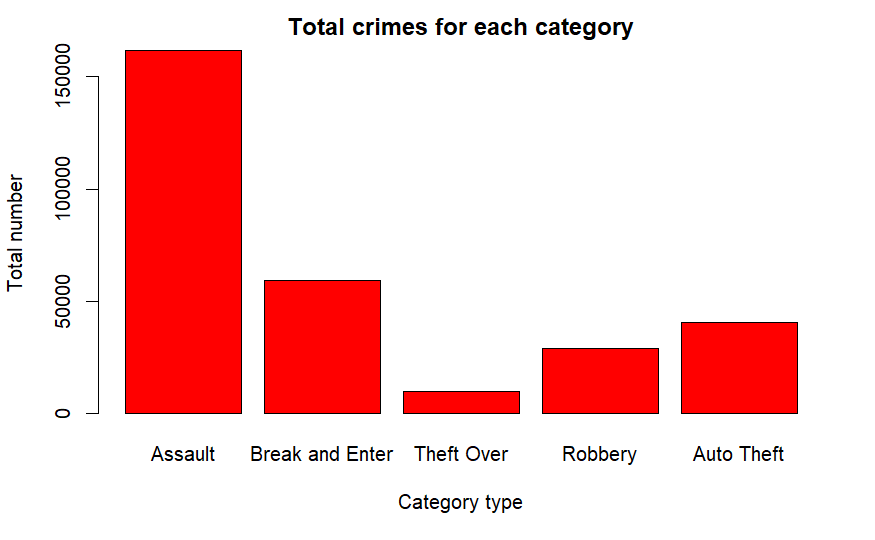

```r
counts<-tabulate(match(dataset$mci_category, uniqx))
barplot(counts, main = "Total crimes for each category", names.arg = uniqx,
                          xlab = "Category type", ylab = "Total number",
                          col = "red")
```

Total crimes for different categories of Theft Over as it is the least frequent crime type

```r
theft_over_rows<-dataset[dataset$mci_category == 'Theft Over',]
theft_over_offence<-unique(na.omit(theft_over_rows$offence))
theft_over_offence[2]
```

```
[1] "Theft From Motor Vehicle Over"
```

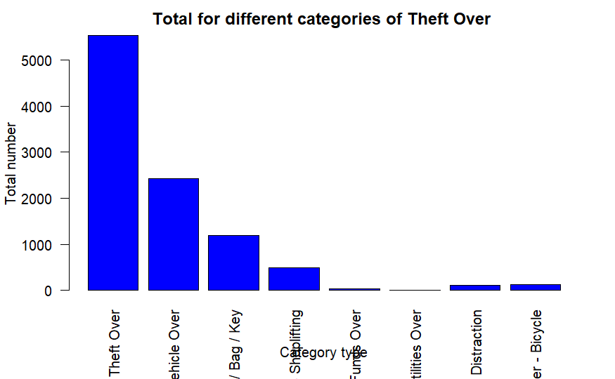

```r
counts<-tabulate(match(theft_over_rows$offence, theft_over_offence))
#par(mar = c(10, 4, 10, 1))
barplot(counts, main = "Total for different categories of Theft Over ", names.arg = theft_over_offence, xlab = "Category type", ylab = "Total number", col = "blue", las = 2)
```

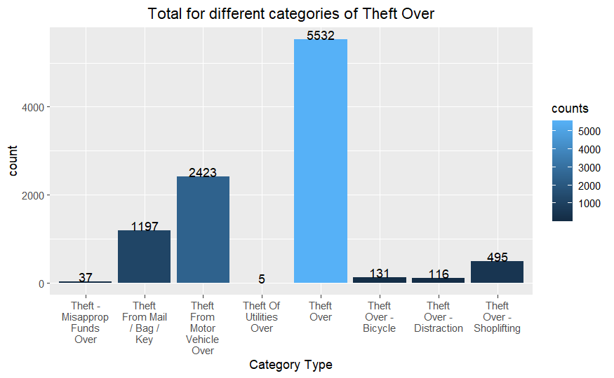

```r
library(ggplot2)
library(scales)
df<-data.frame(counts,theft_over_offence)
p<-ggplot(data=df, aes(x=theft_over_offence, y=counts,fill=counts))+geom_bar(stat="identity")  +scale_x_discrete(labels = wrap_format(10))+geom_text(aes(label = counts), vjust = 0)+ggtitle(label="Total for different categories of Theft Over")+xlab(label="Category Type")+ylab("count")
p
```

Most frequent Category of Auto theft

```r
theft_over_rows<-dataset[dataset$mci_category == 'Auto Theft',]
theft_over_offence<-unique(na.omit(theft_over_rows$offence))
theft_over_offence
```

```
[1] "Theft Of Motor Vehicle"
```

Assault insights Total crimes for different categories of Assault as it is the most frequent category

```r
theft_over_rows<-dataset[dataset$mci_category == 'Assault',]
theft_over_offence<-unique(na.omit(theft_over_rows$offence))
theft_over_offence
```

```
 [1] "Assault"                        "Assault - Force/Thrt/Impede"    "Assault Peace Officer"
 [4] "Assault With Weapon"            "Assault - Resist/ Prevent Seiz" "Pointing A Firearm"
 [7] "Aggravated Assault"             "Assault Bodily Harm"            "Discharge Firearm With Intent"
[10] "Crim Negligence Bodily Harm"    "Administering Noxious Thing"    "Discharge Firearm - Recklessly"
[13] "Assault Peace Officer Wpn/Cbh"  "Unlawfully Causing Bodily Harm" "Use Firearm / Immit Commit Off"
[16] "Aggravated Assault Avails Pros" "Aggravated Aslt Peace Officer"  "Disarming Peace/Public Officer"
[19] "Air Gun Or Pistol: Bodily Harm" "Traps Likely Cause Bodily Harm" "Set/Place Trap/Intend Death/Bh"
[22] "Hoax Terrorism Causing Bodily"
```

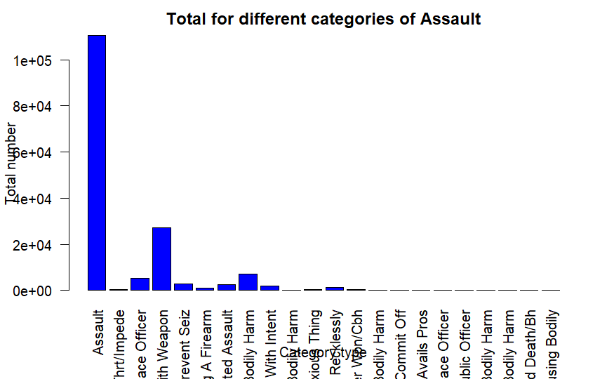

```r
counts<-tabulate(match(theft_over_rows$offence, theft_over_offence))
#par(mar = c(10, 4, 10, 1))
barplot(counts, main = "Total for different categories of Assault", names.arg = theft_over_offence,
                          xlab = "Category type", ylab = "Total number",
                          col = "blue", las = 2)
```

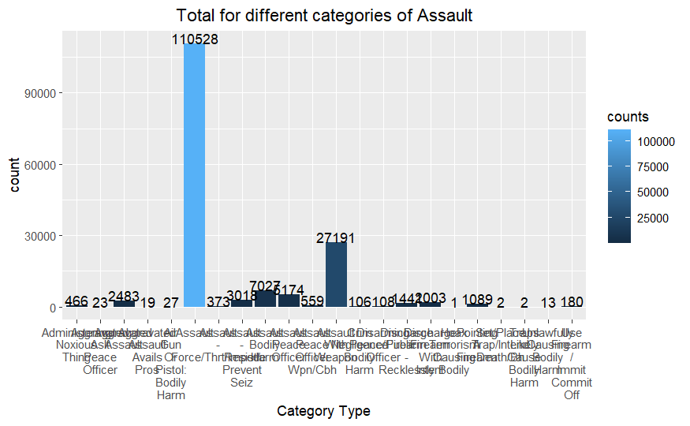

```r
library(ggplot2)
library(scales)
df <- data.frame(counts, theft_over_offence)
options(repr.plot.width = 500, repr.plot.height =3)
theme_update(plot.title = element_text(hjust = 0.5))
p<-ggplot(data=df, aes(x=theft_over_offence, y=counts,fill=counts))+geom_bar(stat="identity")  +scale_x_discrete(labels = wrap_format(5))+geom_text(aes(label = counts), vjust = 0)+ggtitle(label="Total for different categories of Assault")+xlab(label="Category Type")+ylab("count")

p
```

Neighbourhood insights

Most dangerous Neighborhood analysis Waterfront Communities-The Island is the most unsafe place

```r
  Neighbour <- unique(na.omit(dataset$Neighbourhood))

  most_dangerous_n<-Neighbour[which.max(tabulate(match(dataset$Neighbourhood, Neighbour)))]
  most_dangerous_n
```

```
[1] "Waterfront Communities-The Island"
```

Waterfront Communities-The Island insights Assault is the most frequent type of crime in the most dangerous neighborhood

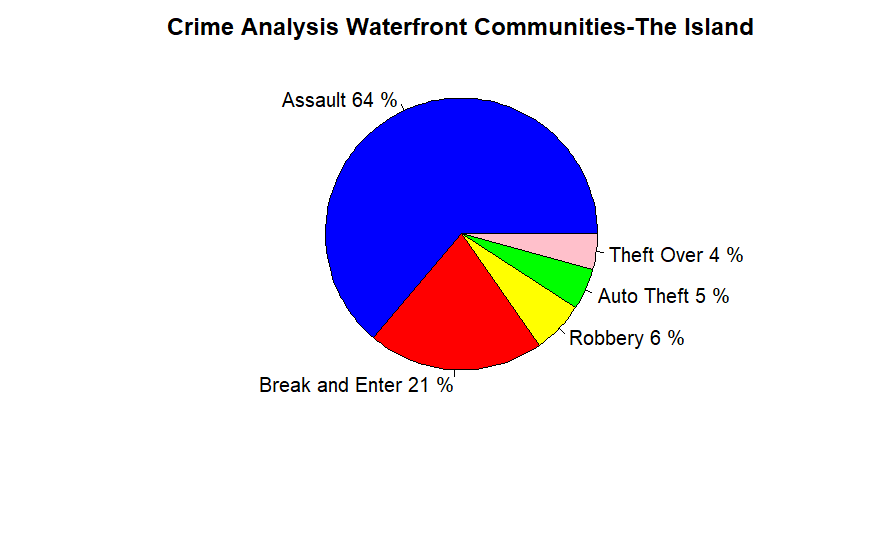

```r
neighbor_analysis<-dataset[dataset$Neighbourhood == most_dangerous_n,]
neighbor_crimes<-unique(na.omit(neighbor_analysis$mci_category))
counts<-tabulate(match(neighbor_analysis$mci_category, neighbor_crimes))
pie(c(counts),labels=paste(neighbor_crimes,round(100*counts/sum(counts),0),"%"),col=c("blue","red","yellow","green","pink","magenta","gray"),main=paste("Crime Analysis",most_dangerous_n))
```

Least Dangerous neighborhood analysis

```r
 least_dangerous_n<-Neighbour[which.min(tabulate(match(dataset$Neighbourhood, Neighbour)))]
least_dangerous_n
```

```
[1] "Lambton Baby Point"
```

```r
neighbor_analysis<-dataset[dataset$Neighbourhood == least_dangerous_n,]
neighbor_crimes<-unique(na.omit(neighbor_analysis$mci_category))
counts<-tabulate(match(neighbor_analysis$mci_category, neighbor_crimes))
typeof(counts)
```

```
[1] "integer"
```

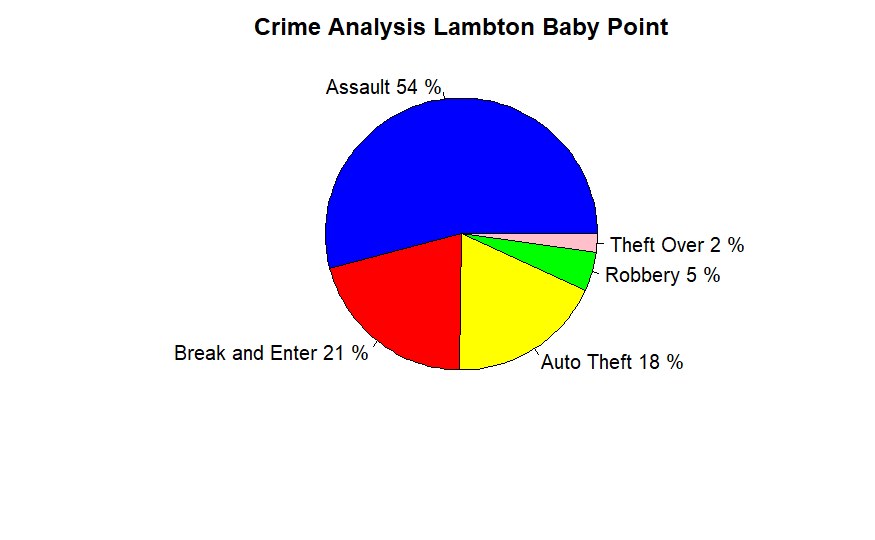

```r
pie(c(counts),labels=paste(neighbor_crimes,round(100*counts/sum(counts),0),"%"),col=c("blue","red","yellow","green","pink","magenta","gray"),main=paste("Crime Analysis",least_dangerous_n))
```

Crime Rate over Years 1966-2022 As the graph shows the crime rate kept increasing from 2014 till 2019 2019 was the peak then the rate dropped until now, this means that the police station implemented better security precautions

```r
years <- unique(na.omit(dataset$occurrenceyear))
years[which.max(tabulate(match(dataset$occurrenceyear, years)))]
```

```
[1] "2019"
```

```r
count<-tabulate(match(dataset$occurrenceyear, years))


library(ggplot2)
#ggplot(mapping= aes(x=months, y=count, group=0)) +geom_line()+geom_point()+geom_line()+ggtitle("Crimes across all months")
# Second variable

val<-data.frame(years,count)
val
```

| years | count |
| --- | --- |
| 2014 | 32467 |
| 2013 | 596 |
| 1996 | 9 |
| 2012 | 186 |
| 1998 | 11 |
| 2003 | 15 |
| 1980 | 5 |
| 2009 | 73 |
| 2011 | 130 |
| 2004 | 27 |

[output cut: 38 more lines]

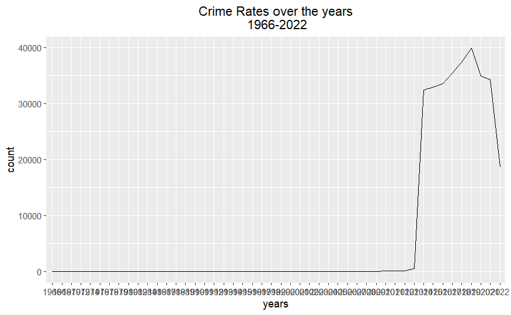

```r
theme_update(plot.title = element_text(hjust = 0.5))
ggplot(data=val, aes(x=years, y=count, group=2)) +geom_line()+ggtitle(label="Crime Rates over the years\n 1966-2022")
```

Crime rate analysis of months

```r
months <- unique(na.omit(dataset$occurrencemonth))
months
```

```
 [1]  1 12 11  9  3  6  5  7 10  2  8  4
```

```r
count<-tabulate(match(dataset$occurrencemonth, months))
count
```

```
 [1] 25744 23084 24222 24430 25493 27476 27479 25176 25291 22882 24900 25056
```

```r
#plot(y=count,type = "o", col = "red", xlab = "Years", ylab = "Rain fall", main = "Crimes rate across months of all years", x=months,xlim=c(1,12))

library(ggplot2)
#ggplot(mapping= aes(x=months, y=count, group=0)) +geom_line()+geom_point()+geom_line()+ggtitle("Crimes across all months")
# Second variable
levels(factor(dataset$occurrencemonth))
```

```
 [1] "1"  "2"  "3"  "4"  "5"  "6"  "7"  "8"  "9"  "10" "11" "12"
```

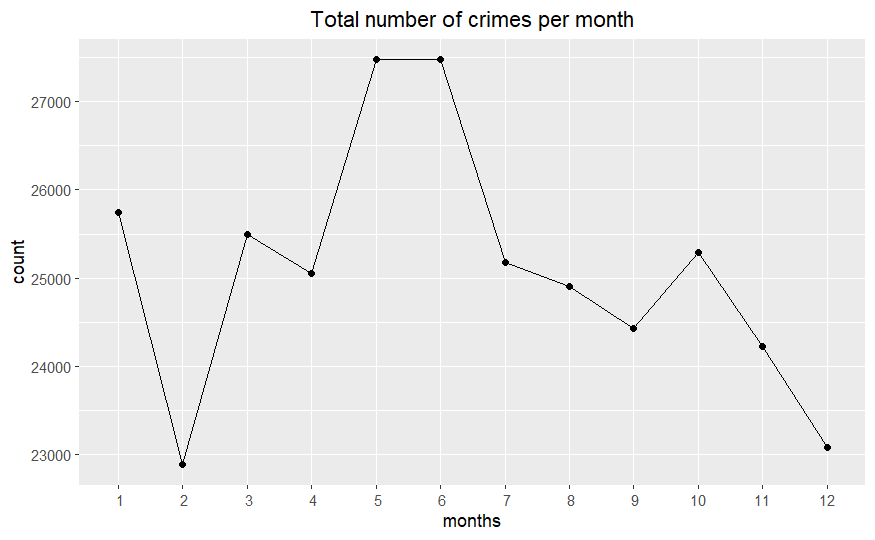

```r
val<-data.frame(months,count)
theme_update(plot.title = element_text(hjust = 0.5))
ggplot(data=val, aes(x=months, y=count, group=1)) +geom_line()+
  geom_point()+xlim(1, 12)+scale_x_discrete(limits=(1:12))+ggtitle(label="Total number of crimes per month")
```

Time difference between occurence and reporting

```r
s <-aggregate(x= difftime(dataset$reporteddate, dataset$occurrencedate, units = "days") ,by = list(dataset$mci_categor),FUN = mean,na.rm=TRUE)

mean_time_difference<-data.frame(s)
mean_time_difference
```

| Group.1 | x |
| --- | --- |
| Assault | 36.003235 days |
| Auto Theft | 6.995368 days |
| Break and Enter | 5.468852 days |
| Robbery | 2.993008 days |
| Theft Over | 48.064366 days |

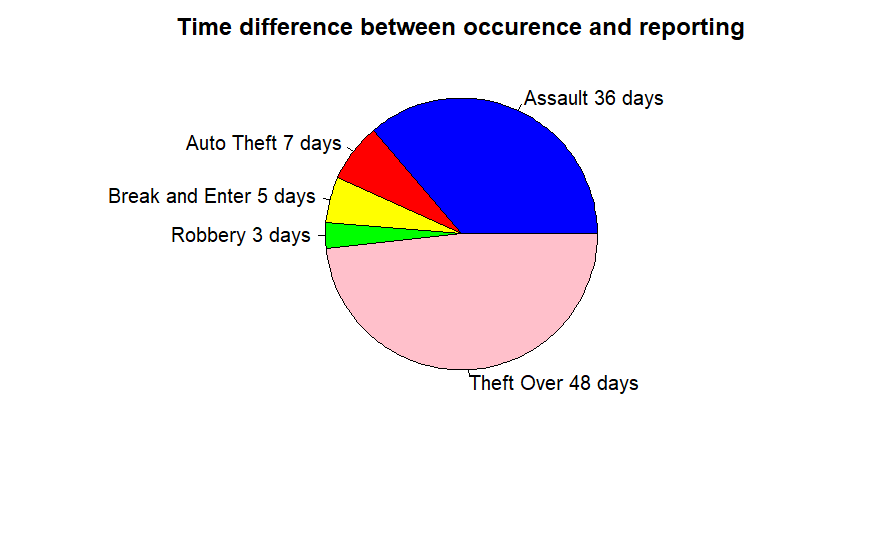

```r
mean_num<-as.numeric(mean_time_difference$x)
pie(c(mean_num),labels=paste(mean_time_difference$Group.1,round((mean_num),0),"days"),col=c("blue","red","yellow","green","pink","magenta","gray"),main=paste("Time difference between occurence and reporting"))
```

insights on premises We calculated the most frequent premises type in which each category of crime occurs

```r
Mode <- function(x) {
  ux <- unique(x)
  ux[which.max(tabulate(match(x, ux)))]
}

t<-aggregate(x=dataset$premises_type  ,by = list(dataset$mci_category),FUN = Mode)
t
```

| Group.1 | x |
| --- | --- |
| Assault | Apartment |
| Auto Theft | Outside |
| Break and Enter | Commercial |
| Robbery | Outside |
| Theft Over | Commercial |

```r
NA
```

Day of the week on which the most number of crimes occur we calculated the most frequent day on which each type of crime occured we also represented the frequency of crimes per days of the week using a bar chart

```r
Mode <- function(x) {
  ux <- unique(x)
  ux[which.max(tabulate(match(x, ux)))]
}
day <- unique(na.omit(dataset$occurrencedayofweek))
day[1]
```

```
[1] "Friday"
```

```r
count<-tabulate(match(dataset$occurrencedayofweek, day))
count
```

```
[1] 45543 42386 41294 42391 44657 41943 43019
```

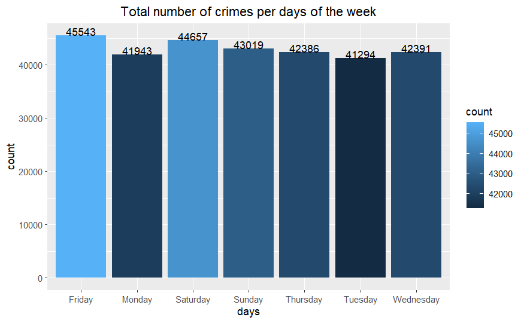

```r
library(ggplot2)
df<-data.frame(day,count)
theme_update(plot.title = element_text(hjust = 0.5))
p<-ggplot(data=df, aes(x=day, y=count,fill=count))+geom_bar(stat="identity")  +geom_text(aes(label = count), vjust = 0)+ggtitle(label="Total number of crimes per days of the week")+xlab(label="days")+ylab("count")
p
```

```r
days<-aggregate(x=dataset$occurrencedayofweek  ,by = list(dataset$mci_category),FUN = Mode)
days
```

| Group.1 | x |
| --- | --- |
| Assault | Saturday |
| Auto Theft | Thursday |
| Break and Enter | Friday |
| Robbery | Friday |
| Theft Over | Friday |

```r
NA
```